# Decision Tree Modeling for Predicting Loan Default

storera17

August 09, 2026

# 1 **Introduction**

Decision tree models are supervised machine learning algorithms used for both classification and regression problems. In classification settings, decision trees predict a categorical outcome by recursively partitioning the data into increasingly homogeneous subgroups based on predictor variables. Each split represents an explicit decision rule, making the model structure transparent and interpretable. This interpretability is especially useful in applied prediction problems, such as loan default classification, where understanding how borrower and loan characteristics contribute to predicted risk is important.

A decision tree is composed of internal nodes, branches, and terminal nodes. Internal nodes represent decision rules based on predictor variables, whereas branches represent the outcomes of those rules. Terminal nodes, also called leaf nodes, contain the final predicted class. In a binary loan default problem, each terminal node classifies observations as either default or non-default, typically according to the majority class within that node. Terminal nodes may also report the number of observations from each class, allowing the analyst to assess node purity and classification confidence.

Decision trees are commonly constructed using recursive partitioning. This process begins with the full training dataset and evaluates possible splits across all predictors. For numeric predictors, the algorithm considers possible cutoff values; for categorical predictors, it evaluates possible groupings of categories. The best split is selected according to an impurity criterion, such as the Gini index or entropy. A split is preferred when it produces child nodes that are more homogeneous than the parent node. This process is repeated recursively until a stopping rule is met, such as a maximum tree depth, a minimum number of observations per node, or insufficient improvement in node purity.

Several algorithms can be used to construct decision trees, including Classification and Regression Trees (CART), C4.5, and Chi-Squared Automatic Interaction Detection (CHAID). CART is commonly implemented in R through the rpart package and uses binary splits based on either the Gini index or information gain. In contrast, C4.5 may use multiway splits and information gain ratio, while CHAID relies on chi-squared tests of independence. In this analysis, CART-based classification trees were used because the response variable, `loan_default`, is categorical.

Although decision trees offer practical advantages, including ease of interpretation, low deployment cost, and robustness to outliers, they are prone to overfitting. A very deep tree can capture noise in the training data and perform poorly on unseen observations. To reduce this risk, tree complexity can be controlled during model training through parameters such as maximum depth, minimum split size, minimum terminal node size, and the complexity parameter. In addition, pruning can be used after an initial tree is grown to remove branches that contribute little predictive value. Cross-validation provides a systematic way to select the appropriate pruning level by estimating model performance across multiple training-validation partitions.

In this project, decision tree models were evaluated as interpretable baseline classifiers for predicting loan default. Both Gini-based and entropy-based splitting rules were considered, along with shallow, deeper, pruned, and cross-validated tree variants. Model performance was assessed using holdout predictions and classification metrics, including F1 score, accuracy, precision, recall, balanced accuracy, and area under the receiver operating characteristic curve. This approach allowed decision trees to be compared with more complex models while preserving a transparent benchmark for understanding borrower default risk.

# 2 **Read in the Data**

## 2.1 *Training Dataset*

```r
train <- readRDS("train.rds")
```

## 2.2 *Undersampled Training Dataset*

```r
train_under <- readRDS("train_under.rds")
```

## 2.3 *Holdout Dataset*

```r
hold <- readRDS("holdout.rds")
```

# 3 **Preview the Data**

## 3.1 *Training Dataset*

```r
skimr::skim(train)
```

Data summary

| Name | train |
| --- | --- |
| Number of rows | 237730 |
| Number of columns | 52 |
| _______________________ |  |
| Column type frequency: |  |
| factor | 15 |
| numeric | 37 |
| ________________________ |  |
| Group variables | None |

**Variable type: factor**

| skim_variable | n_missing | complete_rate | ordered | n_unique | top_counts |
| --- | --- | --- | --- | --- | --- |
| loan_default | 0 | 1 | FALSE | 2 | No: 191095, Yes: 46635 |
| emp_length | 0 | 1 | FALSE | 12 | 10+: 75581, 2 y: 21531, < 1: 19068, 3 y: 19024 |
| home_ownership | 0 | 1 | FALSE | 4 | MOR: 118808, REN: 96106, OWN: 22723, Oth: 93 |
| verification_status | 0 | 1 | FALSE | 3 | Ver: 83840, Sou: 78761, Not: 75129, Mis: 0 |
| purpose | 0 | 1 | FALSE | 9 | deb: 140874, cre: 49826, hom: 14394, oth: 12661 |
| initial_list_status | 0 | 1 | FALSE | 2 | f: 142760, w: 94970, Mis: 0, Oth: 0 |
| application_type | 0 | 1 | FALSE | 2 | IND: 237305, Oth: 425, Mis: 0 |
| hardship_flag | 0 | 1 | FALSE | 1 | N: 237730, Mis: 0, Oth: 0 |
| debt_settlement_flag | 0 | 1 | FALSE | 2 | N: 234626, Y: 3104, Mis: 0, Oth: 0 |
| pub_rec_group | 0 | 1 | FALSE | 3 | 0: 203275, 1: 29665, 2+: 4790, Mis: 0 |
| recent_inquiry_group | 0 | 1 | FALSE | 3 | 0: 123467, 1: 67522, 2+: 46741, Mis: 0 |
| any_pub_record | 0 | 1 | FALSE | 2 | No: 203275, Yes: 34455, Mis: 0, Oth: 0 |
| any_bankruptcy | 0 | 1 | FALSE | 2 | No: 210772, Yes: 26958, Mis: 0, Oth: 0 |
| any_current_delinq | 0 | 1 | FALSE | 2 | No: 236797, Oth: 933, Mis: 0 |
| zip_code | 0 | 1 | FALSE | 10 | 704: 34255, 307: 34160, 226: 33948, 480: 33515 |

**Variable type: numeric**

| skim_variable | n_missing | complete_rate | mean | sd | p0 | p25 | p50 | p75 | p100 | hist |
| --- | --- | --- | --- | --- | --- | --- | --- | --- | --- | --- |
| loan_amnt | 0 | 1 | 14104.14 | 8345.98 | 500.00 | 8000.00 | 12000.00 | 20000.00 | 35000.00 | ▆▇▆▂▂ |
| term | 0 | 1 | 41.68 | 10.20 | 36.00 | 36.00 | 36.00 | 36.00 | 60.00 | ▇▁▁▁▂ |
| int_rate | 0 | 1 | 13.63 | 4.47 | 5.32 | 10.39 | 13.33 | 16.49 | 30.99 | ▅▇▅▁▁ |
| dti | 0 | 1 | 17.33 | 8.07 | 0.00 | 11.29 | 16.90 | 23.00 | 36.43 | ▃▇▇▅▂ |
| open_acc | 0 | 1 | 11.26 | 4.95 | 0.00 | 8.00 | 10.00 | 14.00 | 27.00 | ▂▇▇▂▁ |
| pub_rec | 0 | 1 | 0.17 | 0.42 | 0.00 | 0.00 | 0.00 | 0.00 | 2.00 | ▇▁▁▁▁ |
| revol_bal | 0 | 1 | 15158.43 | 14082.95 | 0.00 | 6015.00 | 11182.00 | 19618.75 | 85253.91 | ▇▂▁▁▁ |
| revol_util | 0 | 1 | 53.75 | 24.49 | 0.00 | 35.80 | 54.70 | 72.80 | 892.30 | ▇▁▁▁▁ |
| total_acc | 0 | 1 | 25.41 | 11.88 | 2.00 | 17.00 | 24.00 | 32.00 | 150.00 | ▇▃▁▁▁ |
| mort_acc | 0 | 1 | 1.71 | 1.95 | 0.00 | 0.00 | 1.00 | 3.00 | 8.00 | ▇▃▁▁▁ |
| delinq_2yrs | 0 | 1 | 0.28 | 0.81 | 0.00 | 0.00 | 0.00 | 0.00 | 29.00 | ▇▁▁▁▁ |
| mths_since_last_delinq | 0 | 1 | 547.89 | 481.38 | 0.00 | 34.00 | 999.00 | 999.00 | 999.00 | ▇▁▁▁▇ |
| emp_length_numeric | 0 | 1 | 5.94 | 3.56 | 0.00 | 3.00 | 6.00 | 10.00 | 10.00 | ▅▃▃▂▇ |
| no_delinq_history_flag | 0 | 1 | 0.53 | 0.50 | 0.00 | 0.00 | 1.00 | 1.00 | 1.00 | ▇▁▁▁▇ |
| grade_score | 0 | 1 | 2.82 | 1.33 | 1.00 | 2.00 | 3.00 | 4.00 | 7.00 | ▇▅▃▂▁ |
| sub_grade_score | 0 | 1 | 16.61 | 9.74 | 1.00 | 9.00 | 16.00 | 24.00 | 35.00 | ▇▇▇▇▇ |
| fico_score | 0 | 1 | 698.58 | 31.64 | 632.00 | 672.00 | 692.00 | 712.00 | 847.50 | ▃▇▂▁▁ |
| fico_range_width | 0 | 1 | 4.00 | 0.01 | 4.00 | 4.00 | 4.00 | 4.00 | 5.00 | ▇▁▁▁▁ |
| issue_year | 0 | 1 | 2013.62 | 1.49 | 2007.00 | 2013.00 | 2014.00 | 2015.00 | 2016.00 | ▁▁▂▇▅ |
| credit_history_days_at_issue | 0 | 1 | 5754.72 | 2633.46 | 1095.00 | 3987.00 | 5236.00 | 7061.00 | 23407.00 | ▇▆▁▁▁ |
| credit_history_years_at_issue | 0 | 1 | 15.76 | 7.21 | 3.00 | 10.92 | 14.34 | 19.33 | 64.08 | ▇▆▁▁▁ |
| last_pull_after_issue_days | 0 | 1 | 1324.47 | 656.04 | -853.00 | 853.00 | 1280.00 | 1767.00 | 4291.00 | ▁▇▇▁▁ |
| loan_to_income | 0 | 1 | 0.23 | 7.59 | 0.00 | 0.13 | 0.20 | 0.29 | 3700.00 | ▇▁▁▁▁ |
| installment_to_monthly_income | 0 | 1 | 0.08 | 0.26 | 0.00 | 0.05 | 0.07 | 0.11 | 123.94 | ▇▁▁▁▁ |
| installment_to_loanamt | 0 | 1 | 0.03 | 0.00 | 0.00 | 0.03 | 0.03 | 0.03 | 0.04 | ▁▁▂▇▂ |
| revol_bal_to_income | 0 | 1 | 0.27 | 21.84 | 0.00 | 0.10 | 0.18 | 0.30 | 10649.00 | ▇▁▁▁▁ |
| total_credit_lines_per_open | 0 | 1 | 2.39 | 1.05 | 1.00 | 1.69 | 2.17 | 2.80 | 34.00 | ▇▁▁▁▁ |
| annual_inc_outlier_flag | 0 | 1 | 0.01 | 0.09 | 0.00 | 0.00 | 0.00 | 0.00 | 1.00 | ▇▁▁▁▁ |
| dti_outlier_flag | 0 | 1 | 0.01 | 0.10 | 0.00 | 0.00 | 0.00 | 0.00 | 1.00 | ▇▁▁▁▁ |
| open_acc_outlier_flag | 0 | 1 | 0.01 | 0.10 | 0.00 | 0.00 | 0.00 | 0.00 | 1.00 | ▇▁▁▁▁ |
| pub_rec_outlier_flag | 0 | 1 | 0.01 | 0.08 | 0.00 | 0.00 | 0.00 | 0.00 | 1.00 | ▇▁▁▁▁ |
| revol_bal_outlier_flag | 0 | 1 | 0.01 | 0.10 | 0.00 | 0.00 | 0.00 | 0.00 | 1.00 | ▇▁▁▁▁ |
| mort_acc_outlier_flag | 0 | 1 | 0.01 | 0.10 | 0.00 | 0.00 | 0.00 | 0.00 | 1.00 | ▇▁▁▁▁ |
| loan_amnt_outlier_flag | 0 | 1 | 0.00 | 0.03 | 0.00 | 0.00 | 0.00 | 0.00 | 1.00 | ▇▁▁▁▁ |
| log_annual_inc | 0 | 1 | 11.06 | 0.51 | 0.00 | 10.71 | 11.07 | 11.41 | 12.43 | ▁▁▁▁▇ |
| log_revol_bal | 0 | 1 | 9.18 | 1.22 | 0.00 | 8.70 | 9.32 | 9.88 | 11.35 | ▁▁▁▅▇ |
| log_loan_amnt | 0 | 1 | 9.35 | 0.68 | 6.22 | 8.99 | 9.39 | 9.90 | 10.46 | ▁▁▃▇▇ |

## 3.2 *Undersampled Training Dataset*

```r
skimr::skim(train_under)
```

Data summary

| Name | train_under |
| --- | --- |
| Number of rows | 93270 |
| Number of columns | 52 |
| _______________________ |  |
| Column type frequency: |  |
| factor | 15 |
| numeric | 37 |
| ________________________ |  |
| Group variables | None |

**Variable type: factor**

| skim_variable | n_missing | complete_rate | ordered | n_unique | top_counts |
| --- | --- | --- | --- | --- | --- |
| loan_default | 0 | 1 | FALSE | 2 | No: 46635, Yes: 46635 |
| emp_length | 0 | 1 | FALSE | 12 | 10+: 28992, 2 y: 8383, < 1: 7602, 3 y: 7453 |
| home_ownership | 0 | 1 | FALSE | 4 | MOR: 44247, REN: 39884, OWN: 9107, Oth: 32 |
| verification_status | 0 | 1 | FALSE | 3 | Ver: 34575, Sou: 31918, Not: 26777, Mis: 0 |
| purpose | 0 | 1 | FALSE | 9 | deb: 56493, cre: 18407, hom: 5379, oth: 5048 |
| initial_list_status | 0 | 1 | FALSE | 2 | f: 55713, w: 37557, Mis: 0, Oth: 0 |
| application_type | 0 | 1 | FALSE | 2 | IND: 93086, Oth: 184, Mis: 0 |
| hardship_flag | 0 | 1 | FALSE | 1 | N: 93270, Mis: 0, Oth: 0 |
| debt_settlement_flag | 0 | 1 | FALSE | 2 | N: 90166, Y: 3104, Mis: 0, Oth: 0 |
| pub_rec_group | 0 | 1 | FALSE | 3 | 0: 79181, 1: 12097, 2+: 1992, Mis: 0 |
| recent_inquiry_group | 0 | 1 | FALSE | 3 | 0: 46636, 1: 26908, 2+: 19726, Mis: 0 |
| any_pub_record | 0 | 1 | FALSE | 2 | No: 79181, Yes: 14089, Mis: 0, Oth: 0 |
| any_bankruptcy | 0 | 1 | FALSE | 2 | No: 82385, Yes: 10885, Mis: 0, Oth: 0 |
| any_current_delinq | 0 | 1 | FALSE | 2 | No: 92861, Oth: 409, Mis: 0 |
| zip_code | 0 | 1 | FALSE | 10 | 307: 13459, 704: 13358, 226: 13338, 480: 13269 |

**Variable type: numeric**

| skim_variable | n_missing | complete_rate | mean | sd | p0 | p25 | p50 | p75 | p100 | hist |
| --- | --- | --- | --- | --- | --- | --- | --- | --- | --- | --- |
| loan_amnt | 0 | 1 | 14469.43 | 8425.63 | 750.00 | 8000.00 | 12375.00 | 20000.00 | 35000.00 | ▆▇▆▃▂ |
| term | 0 | 1 | 42.98 | 10.90 | 36.00 | 36.00 | 36.00 | 60.00 | 60.00 | ▇▁▁▁▃ |
| int_rate | 0 | 1 | 14.45 | 4.58 | 5.32 | 11.14 | 14.09 | 17.57 | 30.99 | ▃▇▆▂▁ |
| dti | 0 | 1 | 18.12 | 8.23 | 0.00 | 12.00 | 17.78 | 23.95 | 36.43 | ▂▆▇▆▃ |
| open_acc | 0 | 1 | 11.36 | 4.98 | 0.00 | 8.00 | 11.00 | 14.00 | 27.00 | ▂▇▇▂▁ |
| pub_rec | 0 | 1 | 0.17 | 0.43 | 0.00 | 0.00 | 0.00 | 0.00 | 2.00 | ▇▁▁▁▁ |
| revol_bal | 0 | 1 | 15036.41 | 13771.66 | 0.00 | 6043.00 | 11183.00 | 19575.75 | 85253.91 | ▇▂▁▁▁ |
| revol_util | 0 | 1 | 55.24 | 24.31 | 0.00 | 37.80 | 56.40 | 74.10 | 892.30 | ▇▁▁▁▁ |
| total_acc | 0 | 1 | 25.22 | 11.89 | 2.00 | 16.00 | 24.00 | 32.00 | 150.00 | ▇▃▁▁▁ |
| mort_acc | 0 | 1 | 1.61 | 1.91 | 0.00 | 0.00 | 1.00 | 3.00 | 8.00 | ▇▃▁▁▁ |
| delinq_2yrs | 0 | 1 | 0.30 | 0.83 | 0.00 | 0.00 | 0.00 | 0.00 | 22.00 | ▇▁▁▁▁ |
| mths_since_last_delinq | 0 | 1 | 543.30 | 481.85 | 0.00 | 33.00 | 999.00 | 999.00 | 999.00 | ▇▁▁▁▇ |
| emp_length_numeric | 0 | 1 | 5.90 | 3.55 | 0.00 | 3.00 | 6.00 | 10.00 | 10.00 | ▆▃▃▂▇ |
| no_delinq_history_flag | 0 | 1 | 0.53 | 0.50 | 0.00 | 0.00 | 1.00 | 1.00 | 1.00 | ▇▁▁▁▇ |
| grade_score | 0 | 1 | 3.07 | 1.39 | 1.00 | 2.00 | 3.00 | 4.00 | 7.00 | ▇▆▃▂▁ |
| sub_grade_score | 0 | 1 | 16.95 | 9.71 | 1.00 | 9.00 | 17.00 | 25.00 | 35.00 | ▇▇▇▇▇ |
| fico_score | 0 | 1 | 695.30 | 29.85 | 662.00 | 672.00 | 687.00 | 710.75 | 847.50 | ▇▃▁▁▁ |
| fico_range_width | 0 | 1 | 4.00 | 0.01 | 4.00 | 4.00 | 4.00 | 4.00 | 5.00 | ▇▁▁▁▁ |
| issue_year | 0 | 1 | 2013.70 | 1.44 | 2007.00 | 2013.00 | 2014.00 | 2015.00 | 2016.00 | ▁▁▂▇▅ |
| credit_history_days_at_issue | 0 | 1 | 5704.96 | 2643.95 | 1095.00 | 3955.25 | 5176.00 | 6971.00 | 23407.00 | ▇▅▁▁▁ |
| credit_history_years_at_issue | 0 | 1 | 15.62 | 7.24 | 3.00 | 10.83 | 14.17 | 19.09 | 64.08 | ▇▅▁▁▁ |
| last_pull_after_issue_days | 0 | 1 | 1250.59 | 638.65 | -853.00 | 790.00 | 1187.00 | 1673.00 | 4291.00 | ▁▇▇▁▁ |
| loan_to_income | 0 | 1 | 0.27 | 12.12 | 0.00 | 0.14 | 0.21 | 0.31 | 3700.00 | ▇▁▁▁▁ |
| installment_to_monthly_income | 0 | 1 | 0.08 | 0.41 | 0.00 | 0.05 | 0.08 | 0.11 | 123.94 | ▇▁▁▁▁ |
| installment_to_loanamt | 0 | 1 | 0.03 | 0.00 | 0.00 | 0.03 | 0.03 | 0.03 | 0.04 | ▁▁▃▇▂ |
| revol_bal_to_income | 0 | 1 | 0.35 | 34.87 | 0.00 | 0.10 | 0.19 | 0.31 | 10649.00 | ▇▁▁▁▁ |
| total_credit_lines_per_open | 0 | 1 | 2.35 | 1.04 | 1.00 | 1.67 | 2.12 | 2.75 | 26.00 | ▇▁▁▁▁ |
| annual_inc_outlier_flag | 0 | 1 | 0.01 | 0.09 | 0.00 | 0.00 | 0.00 | 0.00 | 1.00 | ▇▁▁▁▁ |
| dti_outlier_flag | 0 | 1 | 0.01 | 0.12 | 0.00 | 0.00 | 0.00 | 0.00 | 1.00 | ▇▁▁▁▁ |
| open_acc_outlier_flag | 0 | 1 | 0.01 | 0.10 | 0.00 | 0.00 | 0.00 | 0.00 | 1.00 | ▇▁▁▁▁ |
| pub_rec_outlier_flag | 0 | 1 | 0.01 | 0.08 | 0.00 | 0.00 | 0.00 | 0.00 | 1.00 | ▇▁▁▁▁ |
| revol_bal_outlier_flag | 0 | 1 | 0.01 | 0.09 | 0.00 | 0.00 | 0.00 | 0.00 | 1.00 | ▇▁▁▁▁ |
| mort_acc_outlier_flag | 0 | 1 | 0.01 | 0.09 | 0.00 | 0.00 | 0.00 | 0.00 | 1.00 | ▇▁▁▁▁ |
| loan_amnt_outlier_flag | 0 | 1 | 0.00 | 0.02 | 0.00 | 0.00 | 0.00 | 0.00 | 1.00 | ▇▁▁▁▁ |
| log_annual_inc | 0 | 1 | 11.03 | 0.52 | 0.00 | 10.69 | 11.00 | 11.35 | 12.43 | ▁▁▁▁▇ |
| log_revol_bal | 0 | 1 | 9.18 | 1.20 | 0.00 | 8.71 | 9.32 | 9.88 | 11.35 | ▁▁▁▅▇ |
| log_loan_amnt | 0 | 1 | 9.38 | 0.67 | 6.62 | 8.99 | 9.42 | 9.90 | 10.46 | ▁▁▃▇▆ |

## 3.3 *Holdout Dataset*

```r
skimr::skim(hold)
```

Data summary

| Name | hold |
| --- | --- |
| Number of rows | 79242 |
| Number of columns | 52 |
| _______________________ |  |
| Column type frequency: |  |
| factor | 15 |
| numeric | 37 |
| ________________________ |  |
| Group variables | None |

**Variable type: factor**

| skim_variable | n_missing | complete_rate | ordered | n_unique | top_counts |
| --- | --- | --- | --- | --- | --- |
| loan_default | 0 | 1 | FALSE | 2 | No: 63698, Yes: 15544 |
| emp_length | 0 | 1 | FALSE | 12 | 10+: 25277, 2 y: 7132, < 1: 6313, 3 y: 6266 |
| home_ownership | 0 | 1 | FALSE | 4 | MOR: 39833, REN: 31876, OWN: 7503, Oth: 30 |
| verification_status | 0 | 1 | FALSE | 3 | Ver: 27864, Sou: 26299, Not: 25079, Mis: 0 |
| purpose | 0 | 1 | FALSE | 9 | deb: 46939, cre: 16597, hom: 4816, oth: 4199 |
| initial_list_status | 0 | 1 | FALSE | 2 | f: 47727, w: 31515, Mis: 0, Oth: 0 |
| application_type | 0 | 1 | FALSE | 2 | IND: 79096, Oth: 146, Mis: 0 |
| hardship_flag | 0 | 1 | FALSE | 1 | N: 79242, Mis: 0, Oth: 0 |
| debt_settlement_flag | 0 | 1 | FALSE | 2 | N: 78171, Y: 1071, Mis: 0, Oth: 0 |
| pub_rec_group | 0 | 1 | FALSE | 3 | 0: 67518, 1: 10083, 2+: 1641, Mis: 0 |
| recent_inquiry_group | 0 | 1 | FALSE | 3 | 0: 41404, 1: 22464, 2+: 15374, Mis: 0 |
| any_pub_record | 0 | 1 | FALSE | 2 | No: 67518, Yes: 11724, Mis: 0, Oth: 0 |
| any_bankruptcy | 0 | 1 | FALSE | 2 | No: 70141, Yes: 9101, Mis: 0, Oth: 0 |
| any_current_delinq | 0 | 1 | FALSE | 2 | No: 78917, Oth: 325, Mis: 0 |
| zip_code | 0 | 1 | FALSE | 10 | 226: 11394, 704: 11366, 307: 11201, 480: 11128 |

**Variable type: numeric**

| skim_variable | n_missing | complete_rate | mean | sd | p0 | p25 | p50 | p75 | p100 | hist |
| --- | --- | --- | --- | --- | --- | --- | --- | --- | --- | --- |
| loan_amnt | 0 | 1 | 14127.98 | 8353.55 | 500.00 | 8000.00 | 12000.00 | 20000.00 | 35000.00 | ▆▇▆▂▂ |
| term | 0 | 1 | 41.71 | 10.22 | 36.00 | 36.00 | 36.00 | 36.00 | 60.00 | ▇▁▁▁▂ |
| int_rate | 0 | 1 | 13.64 | 4.48 | 5.32 | 10.37 | 13.33 | 16.55 | 30.99 | ▅▇▅▁▁ |
| dti | 0 | 1 | 17.30 | 8.06 | 0.00 | 11.25 | 16.88 | 22.93 | 36.43 | ▃▇▇▅▂ |
| open_acc | 0 | 1 | 11.28 | 4.94 | 0.00 | 8.00 | 10.00 | 14.00 | 27.00 | ▂▇▇▂▁ |
| pub_rec | 0 | 1 | 0.17 | 0.43 | 0.00 | 0.00 | 0.00 | 0.00 | 2.00 | ▇▁▁▁▁ |
| revol_bal | 0 | 1 | 15186.37 | 14179.53 | 0.00 | 6040.00 | 11147.00 | 19555.50 | 85253.91 | ▇▂▁▁▁ |
| revol_util | 0 | 1 | 53.71 | 24.46 | 0.00 | 35.70 | 54.70 | 72.80 | 153.00 | ▃▇▇▁▁ |
| total_acc | 0 | 1 | 25.42 | 11.87 | 2.00 | 17.00 | 24.00 | 32.00 | 135.00 | ▇▅▁▁▁ |
| mort_acc | 0 | 1 | 1.72 | 1.96 | 0.00 | 0.00 | 1.00 | 3.00 | 8.00 | ▇▃▁▁▁ |
| delinq_2yrs | 0 | 1 | 0.28 | 0.83 | 0.00 | 0.00 | 0.00 | 0.00 | 39.00 | ▇▁▁▁▁ |
| mths_since_last_delinq | 0 | 1 | 549.22 | 481.29 | 0.00 | 34.00 | 999.00 | 999.00 | 999.00 | ▇▁▁▁▇ |
| emp_length_numeric | 0 | 1 | 5.95 | 3.56 | 0.00 | 3.00 | 6.00 | 10.00 | 10.00 | ▅▃▃▂▇ |
| no_delinq_history_flag | 0 | 1 | 0.53 | 0.50 | 0.00 | 0.00 | 1.00 | 1.00 | 1.00 | ▇▁▁▁▇ |
| grade_score | 0 | 1 | 2.82 | 1.33 | 1.00 | 2.00 | 3.00 | 4.00 | 7.00 | ▇▅▃▂▁ |
| sub_grade_score | 0 | 1 | 16.68 | 9.72 | 1.00 | 9.00 | 17.00 | 24.00 | 35.00 | ▇▇▇▇▇ |
| fico_score | 0 | 1 | 698.61 | 31.74 | 627.00 | 672.00 | 692.00 | 712.00 | 847.50 | ▂▇▂▁▁ |
| fico_range_width | 0 | 1 | 4.00 | 0.01 | 4.00 | 4.00 | 4.00 | 4.00 | 5.00 | ▇▁▁▁▁ |
| issue_year | 0 | 1 | 2013.63 | 1.48 | 2007.00 | 2013.00 | 2014.00 | 2015.00 | 2016.00 | ▁▁▂▇▅ |
| credit_history_days_at_issue | 0 | 1 | 5750.38 | 2624.24 | 1096.00 | 3987.00 | 5236.00 | 7062.00 | 25627.00 | ▇▅▁▁▁ |
| credit_history_years_at_issue | 0 | 1 | 15.74 | 7.18 | 3.00 | 10.92 | 14.34 | 19.33 | 70.16 | ▇▅▁▁▁ |
| last_pull_after_issue_days | 0 | 1 | 1321.72 | 656.63 | -853.00 | 853.00 | 1280.00 | 1766.00 | 4230.00 | ▁▇▇▂▁ |
| loan_to_income | 0 | 1 | 0.21 | 0.11 | 0.00 | 0.13 | 0.20 | 0.29 | 7.35 | ▇▁▁▁▁ |
| installment_to_monthly_income | 0 | 1 | 0.08 | 0.04 | 0.00 | 0.05 | 0.07 | 0.11 | 2.65 | ▇▁▁▁▁ |
| installment_to_loanamt | 0 | 1 | 0.03 | 0.00 | 0.00 | 0.03 | 0.03 | 0.03 | 0.04 | ▁▁▂▇▂ |
| revol_bal_to_income | 0 | 1 | 0.23 | 0.20 | 0.00 | 0.10 | 0.18 | 0.30 | 5.78 | ▇▁▁▁▁ |
| total_credit_lines_per_open | 0 | 1 | 2.38 | 1.03 | 1.00 | 1.69 | 2.16 | 2.80 | 19.00 | ▇▁▁▁▁ |
| annual_inc_outlier_flag | 0 | 1 | 0.01 | 0.09 | 0.00 | 0.00 | 0.00 | 0.00 | 1.00 | ▇▁▁▁▁ |
| dti_outlier_flag | 0 | 1 | 0.01 | 0.10 | 0.00 | 0.00 | 0.00 | 0.00 | 1.00 | ▇▁▁▁▁ |
| open_acc_outlier_flag | 0 | 1 | 0.01 | 0.10 | 0.00 | 0.00 | 0.00 | 0.00 | 1.00 | ▇▁▁▁▁ |
| pub_rec_outlier_flag | 0 | 1 | 0.01 | 0.08 | 0.00 | 0.00 | 0.00 | 0.00 | 1.00 | ▇▁▁▁▁ |
| revol_bal_outlier_flag | 0 | 1 | 0.01 | 0.10 | 0.00 | 0.00 | 0.00 | 0.00 | 1.00 | ▇▁▁▁▁ |
| mort_acc_outlier_flag | 0 | 1 | 0.01 | 0.10 | 0.00 | 0.00 | 0.00 | 0.00 | 1.00 | ▇▁▁▁▁ |
| loan_amnt_outlier_flag | 0 | 1 | 0.00 | 0.03 | 0.00 | 0.00 | 0.00 | 0.00 | 1.00 | ▇▁▁▁▁ |
| log_annual_inc | 0 | 1 | 11.07 | 0.51 | 7.82 | 10.71 | 11.07 | 11.41 | 12.43 | ▁▁▂▇▂ |
| log_revol_bal | 0 | 1 | 9.18 | 1.22 | 0.00 | 8.71 | 9.32 | 9.88 | 11.35 | ▁▁▁▅▇ |
| log_loan_amnt | 0 | 1 | 9.36 | 0.68 | 6.22 | 8.99 | 9.39 | 9.90 | 10.46 | ▁▁▃▇▇ |

# 4 *Create `evaluate_classifier()`*

```r
evaluate_classifier <- function(actual, predicted, probability_yes, positive_class = "Yes") {
  actual <- factor(actual, levels = c("Yes", "No"))
  predicted <- factor(predicted, levels = c("Yes", "No"))

  cm <- caret::confusionMatrix(
    data = predicted,
    reference = actual,
    positive = positive_class
  )

  roc_obj <- pROC::roc(
    response = actual,
    predictor = probability_yes,
    levels = c("No", "Yes"),
    direction = "<",
    quiet = TRUE
  )

  precision <- cm$byClass["Precision"]
  recall <- cm$byClass["Sensitivity"]
  f1 <- ifelse(
    precision + recall == 0,
    0,
    2 * precision * recall / (precision + recall)
  )

  tibble::tibble(
    accuracy = as.numeric(cm$overall["Accuracy"]),
    balanced_accuracy = as.numeric(cm$byClass["Balanced Accuracy"]),
    precision = as.numeric(precision),
    sensitivity_recall = as.numeric(recall),
    specificity = as.numeric(cm$byClass["Specificity"]),
    f1_score = as.numeric(f1),
    auc = as.numeric(pROC::auc(roc_obj))
  )
}
```

# 5 **Default Tree - Gini Impurity Measure**

## 5.1 *Training Dataset*

### 5.1.1 Build Tree

```r
set.seed(123)

gini_ct = rpart(
  loan_default ~ .,
  data = train,
  method = "class",
  parms=list(split="gini"),
  control=rpart.control(maxdepth=30,
                        minbucket=5,
                        xval=0,
                        cp=0.0002465959))
```

### 5.1.2 Print `cp`

```r
printcp(gini_ct)
```

```
##
## Classification tree:
## rpart(formula = loan_default ~ ., data = train, method = "class",
##     parms = list(split = "gini"), control = rpart.control(maxdepth = 30,
##         minbucket = 5, xval = 0, cp = 0.0002465959))
##
## Variables actually used in tree construction:
##  [1] credit_history_days_at_issue  debt_settlement_flag
##  [3] dti                           emp_length
##  [5] fico_score                    grade_score
##  [7] home_ownership                installment_to_loanamt
##  [9] installment_to_monthly_income int_rate
## [11] issue_year                    last_pull_after_issue_days
## [13] loan_amnt                     loan_to_income
## [15] mort_acc                      mths_since_last_delinq
```

[output cut: 38 more lines]

### 5.1.3 Prune

```r
gini_tree=prune(gini_ct, cp=0.0002465959)
```

### 5.1.4 Print Tree

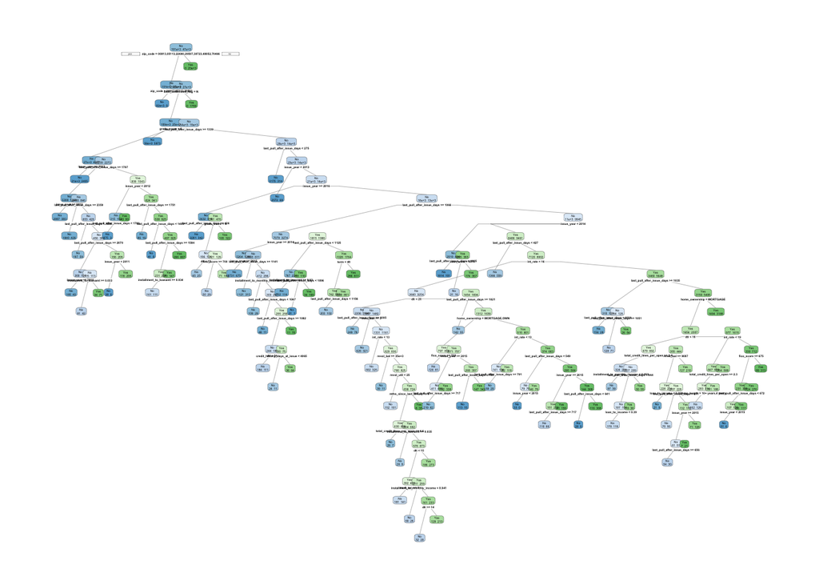

```r
rpart.plot(gini_tree, extra=1, fallen.leaves=FALSE)
```

### 5.1.5 Predict on Holdout Dataset

#### 5.1.5.1 Predict Probabilities

```r
gini_tree_prob <- predict(
  object = gini_tree,
  newdata = hold,
  type = "prob"
)
```

#### 5.1.5.2 Predict Class

```r
gini_tree_class <- predict(
  object = gini_tree,
  newdata = hold,
  type = "class"
)
```

#### 5.1.5.3 Tabulate Predictions

```r
gini_tree_predictions <- tibble::tibble(
  actual = factor(hold$loan_default, levels = c("No", "Yes")),
  predicted = factor(gini_tree_class, levels = c("No", "Yes")),
  probability_yes = as.numeric(gini_tree_prob[, "Yes"])
)
```

#### 5.1.5.4 Preview Table

```r
head(gini_tree_predictions)
```

| actual | predicted | probability_yes |
| --- | --- | --- |
| Yes | Yes | 1.00000000 |
| No | No | 0.00000000 |
| No | Yes | 0.67500000 |
| No | No | 0.00000000 |
| No | No | 0.09439691 |
| No | No | 0.09563278 |

### 5.1.6 Evaluate

```r
gini_tree_metrics <- evaluate_classifier(
  actual = gini_tree_predictions$actual,
  predicted = gini_tree_predictions$predicted,
  probability_yes = gini_tree_predictions$probability_yes
)
```

### 5.1.7 Store & Export

#### 5.1.7.1 Save Model

```r
saveRDS(gini_tree, file.path(project_dir, "gini_tree_model.rds"))
```

#### 5.1.7.2 Save Results

```r
gini_tree_results <- gini_tree_metrics %>%
  mutate(
    model_type = "Pruned Decision Tree ",
    impurity = "Gini Index",
    sample = "Full"
  )

saveRDS(gini_tree_results, file.path(project_dir, "gini_tree_results.rds"))
```

## 5.2 *Undersampled Training Dataset*

### 5.2.1 Build Tree

```r
set.seed(123)
gini_ct_us = rpart(
  loan_default ~ .,
  data = train_under,
  method = "class",
  parms=list(split="gini"),
  control=rpart.control(maxdepth=30,
                        minbucket=5,
                        xval=0,
                        cp=0.0002090704)
  )
```

### 5.2.2 Print `cp`

```r
printcp(gini_ct_us)
```

```
##
## Classification tree:
## rpart(formula = loan_default ~ ., data = train_under, method = "class",
##     parms = list(split = "gini"), control = rpart.control(maxdepth = 30,
##         minbucket = 5, xval = 0, cp = 0.0002090704))
##
## Variables actually used in tree construction:
##  [1] credit_history_days_at_issue  debt_settlement_flag
##  [3] dti                           emp_length
##  [5] fico_score                    grade_score
##  [7] home_ownership                installment_to_loanamt
##  [9] installment_to_monthly_income int_rate
## [11] issue_year                    last_pull_after_issue_days
## [13] loan_amnt                     loan_to_income
## [15] log_annual_inc                open_acc
```

[output cut: 52 more lines]

### 5.2.3 Prune

```r
gini_tree_us=prune(gini_ct_us, cp=0.0002465959)
```

### 5.2.4 Print Tree

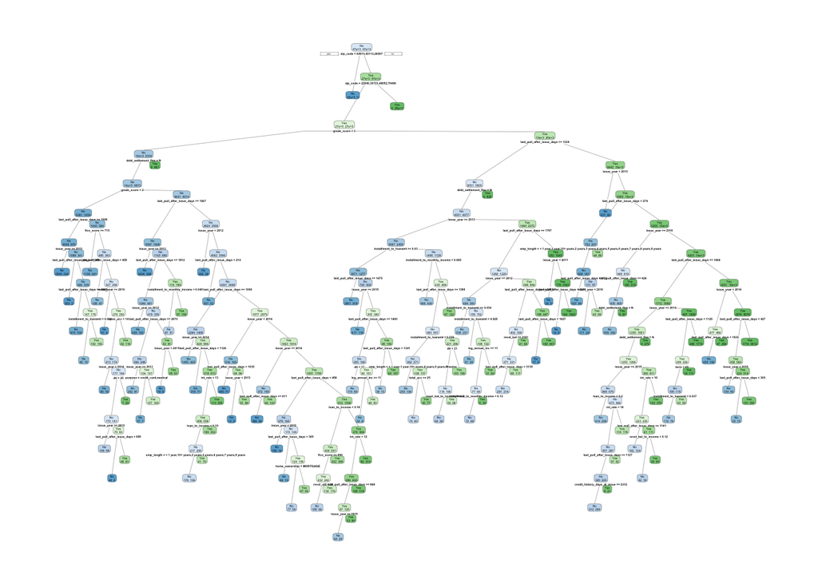

```r
rpart.plot(gini_tree_us, extra=1, fallen.leaves=FALSE)
```

### 5.2.5 Predict on Holdout Dataset

#### 5.2.5.1 Predict Probabilities

```r
gini_tree_prob_us <- predict(
  object = gini_tree_us,
  newdata = hold,
  type = "prob"
)
```

#### 5.2.5.2 Predict Class

```r
gini_tree_class_us <- predict(
  object = gini_tree_us,
  newdata = hold,
  type = "class"
)
```

#### 5.2.5.3 Tabulate Predictions

```r
gini_tree_predictions_us <- tibble::tibble(
  actual = factor(hold$loan_default, levels = c("No", "Yes")),
  predicted = factor(gini_tree_class_us, levels = c("No", "Yes")),
  probability_yes = as.numeric(gini_tree_prob_us[, "Yes"])
)
```

#### 5.2.5.4 Preview Table

```r
head(gini_tree_predictions_us)
```

| actual | predicted | probability_yes |
| --- | --- | --- |
| Yes | Yes | 1.0000000 |
| No | No | 0.0000000 |
| No | Yes | 0.8400447 |
| No | No | 0.0000000 |
| No | No | 0.2905692 |
| No | No | 0.1992925 |

### 5.2.6 Evaluate

```r
gini_tree_metrics_us <- evaluate_classifier(
  actual = gini_tree_predictions_us$actual,
  predicted = gini_tree_predictions_us$predicted,
  probability_yes = gini_tree_predictions_us$probability_yes
)
```

### 5.2.7 Store & Export

#### 5.2.7.1 Save Model

```r
saveRDS(gini_tree_us, file.path(project_dir, "gini_tree_us_model.rds"))
```

#### 5.2.7.2 Save Results

```r
gini_tree_results_us <- gini_tree_metrics_us %>%
  mutate(
    model_type = "Pruned Decision Tree",
    impurity = "Gini Index",
    sample = "Undersampled"
  )

saveRDS(gini_tree_results_us, file.path(project_dir, "gini_tree_us_results.rds"))
```

# 6 **Default Tree - Entropy Index Impurity Measure**

## 6.1 *Training Dataset*

### 6.1.1 Build Tree

```r
set.seed(123)
entropic_ct = rpart(
  loan_default ~ .,
  data = train,
  method = "class",
  parms=list(split="information"),
  control=rpart.control(maxdepth=30,
                        minbucket=5,
                        xval=0,
                        cp=0.0001977532)
  )
```

### 6.1.2 Print `cp`

```r
printcp(entropic_ct)
```

```
##
## Classification tree:
## rpart(formula = loan_default ~ ., data = train, method = "class",
##     parms = list(split = "information"), control = rpart.control(maxdepth = 30,
##         minbucket = 5, xval = 0, cp = 0.0001977532))
##
## Variables actually used in tree construction:
##  [1] credit_history_days_at_issue  debt_settlement_flag
##  [3] dti                           emp_length
##  [5] fico_score                    grade_score
##  [7] home_ownership                installment_to_loanamt
##  [9] installment_to_monthly_income int_rate
## [11] issue_year                    last_pull_after_issue_days
## [13] loan_amnt                     loan_to_income
## [15] mort_acc                      mths_since_last_delinq
```

[output cut: 43 more lines]

### 6.1.3 Prune

```r
entropic_tree=prune(entropic_ct, cp=0.0001977532)
```

### 6.1.4 Print Tree

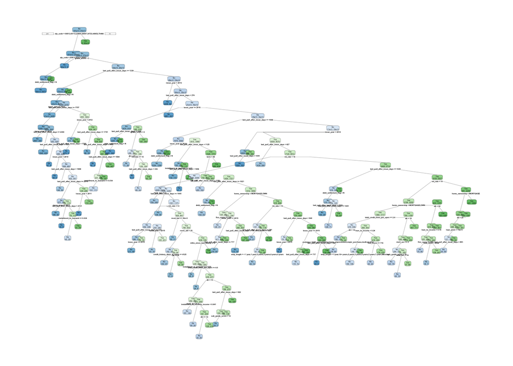

```r
rpart.plot(entropic_tree, extra=1, fallen.leaves=FALSE)
```

### 6.1.5 Predict on Holdout Dataset

#### 6.1.5.1 Predict Probabilities

```r
entropic_tree_prob <- predict(
  object = entropic_tree,
  newdata = hold,
  type = "prob"
)
```

#### 6.1.5.2 Predict Class

```r
entropic_tree_class <- predict(
  object = entropic_tree,
  newdata = hold,
  type = "class"
)
```

#### 6.1.5.3 Tabulate Predictions

```r
entropic_tree_predictions <- tibble::tibble(
  actual = factor(hold$loan_default, levels = c("No", "Yes")),
  predicted = factor(entropic_tree_class, levels = c("No", "Yes")),
  probability_yes = as.numeric(entropic_tree_prob[, "Yes"])
)
```

#### 6.1.5.4 Preview Table

```r
head(entropic_tree_predictions)
```

| actual | predicted | probability_yes |
| --- | --- | --- |
| Yes | Yes | 1.00000000 |
| No | No | 0.00000000 |
| No | Yes | 0.67500000 |
| No | No | 0.00000000 |
| No | No | 0.09439691 |
| No | No | 0.09563278 |

### 6.1.6 Evaluate

```r
entropy_tree_metrics <- evaluate_classifier(
  actual = entropic_tree_predictions$actual,
  predicted = entropic_tree_predictions$predicted,
  probability_yes = entropic_tree_predictions$probability_yes
)
```

### 6.1.7 Store & Export

#### 6.1.7.1 Save Model

```r
saveRDS(entropic_tree, file.path(project_dir, "entropy_tree_model.rds"))
```

#### 6.1.7.2 Save Results

```r
entropy_tree_results <- entropy_tree_metrics %>%
  mutate(
    model_type = "Pruned Decision Tree ",
    impurity = "Entropy Index",
    sample = "Full"
  )

saveRDS(entropy_tree_results, file.path(project_dir, "entropy_tree_results.rds"))
```

## 6.2 *Undersampled Training Dataset*

### 6.2.1 Build Tree

```r
set.seed(123)
entropic_ct_us = rpart(
  loan_default ~ .,
  data = train_under,
  method = "class",
  parms=list(split="information"),
  control=rpart.control(maxdepth=30,
                        minbucket=5,
                        xval=0,
                        cp=0.0001977532)
  )
```

### 6.2.2 Print `cp`

```r
printcp(entropic_ct_us)
```

```
##
## Classification tree:
## rpart(formula = loan_default ~ ., data = train_under, method = "class",
##     parms = list(split = "information"), control = rpart.control(maxdepth = 30,
##         minbucket = 5, xval = 0, cp = 0.0001977532))
##
## Variables actually used in tree construction:
##  [1] credit_history_days_at_issue  debt_settlement_flag
##  [3] dti                           emp_length
##  [5] fico_score                    grade_score
##  [7] home_ownership                installment_to_loanamt
##  [9] installment_to_monthly_income int_rate
## [11] issue_year                    last_pull_after_issue_days
## [13] loan_to_income                log_annual_inc
## [15] mths_since_last_delinq        open_acc
```

[output cut: 53 more lines]

### 6.2.3 Prune

```r
entropic_tree_us=prune(entropic_ct_us, cp=0.0002465959)
```

### 6.2.4 Print Tree

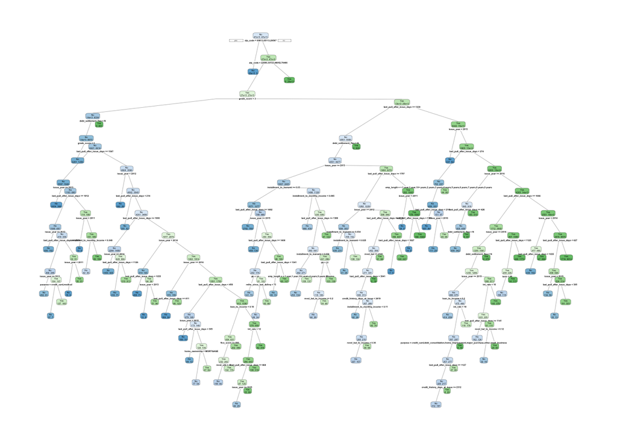

```r
rpart.plot(entropic_tree_us, extra=1, fallen.leaves=FALSE)
```

### 6.2.5 Predict on Holdout Dataset

#### 6.2.5.1 Predict Probabilities

```r
entropic_tree_prob_us <- predict(
  object = entropic_tree_us,
  newdata = hold,
  type = "prob"
)
```

#### 6.2.5.2 Predict Class

```r
entropic_tree_class_us <- predict(
  object = entropic_tree_us,
  newdata = hold,
  type = "class"
)
```

#### 6.2.5.3 Tabulate Predictions

```r
entropic_tree_predictions_us <- tibble::tibble(
  actual = factor(hold$loan_default, levels = c("No", "Yes")),
  predicted = factor(entropic_tree_class_us, levels = c("No", "Yes")),
  probability_yes = as.numeric(entropic_tree_prob_us[, "Yes"])
)
```

#### 6.2.5.4 Preview Table

```r
head(entropic_tree_predictions_us)
```

| actual | predicted | probability_yes |
| --- | --- | --- |
| Yes | Yes | 1.0000000 |
| No | No | 0.0000000 |
| No | Yes | 0.8400447 |
| No | No | 0.0000000 |
| No | No | 0.2905692 |
| No | No | 0.1925076 |

### 6.2.6 Evaluate

```r
entropy_tree_metrics_us <- evaluate_classifier(
  actual = entropic_tree_predictions_us$actual,
  predicted = entropic_tree_predictions_us$predicted,
  probability_yes = entropic_tree_predictions_us$probability_yes
)
```

### 6.2.7 Store & Export

#### 6.2.7.1 Save Model

```r
saveRDS(entropic_tree_us, file.path(project_dir, "entropy_tree_us_model.rds"))
```

#### 6.2.7.2 Save Results

```r
entropy_tree_results_us <- entropy_tree_metrics_us %>%
  mutate(
    model_type = "Pruned Decision Tree ",
    impurity = "Entropy Index",
    sample = "Undersampled"
  )

saveRDS(entropy_tree_results_us, file.path(project_dir, "entropy_tree_us_results.rds"))
```

# 7 **Prune Tree With Cross Validation - Gini Index Impurity Measure**

## 7.1 *Training Dataset*

### 7.1.1 Build Tree

```r
set.seed(123)
cv_gini_ct=rpart(loan_default ~ .,
                 data=train,
                 method="class",
                 parms=list(split="gini"),
                 control=rpart.control(
                   maxdepth=30,
                   cp=0.0001977532,
                   xval=15))
```

### 7.1.2 Print `cp`

```r
printcp(cv_gini_ct)
```

```
##
## Classification tree:
## rpart(formula = loan_default ~ ., data = train, method = "class",
##     parms = list(split = "gini"), control = rpart.control(maxdepth = 30,
##         cp = 0.0001977532, xval = 15))
##
## Variables actually used in tree construction:
##  [1] credit_history_days_at_issue  debt_settlement_flag
##  [3] dti                           emp_length
##  [5] fico_score                    grade_score
##  [7] home_ownership                installment_to_loanamt
##  [9] installment_to_monthly_income int_rate
## [11] issue_year                    last_pull_after_issue_days
## [13] loan_amnt                     loan_to_income
## [15] mort_acc                      mths_since_last_delinq
```

[output cut: 42 more lines]

### 7.1.3 Plot `cp` Values

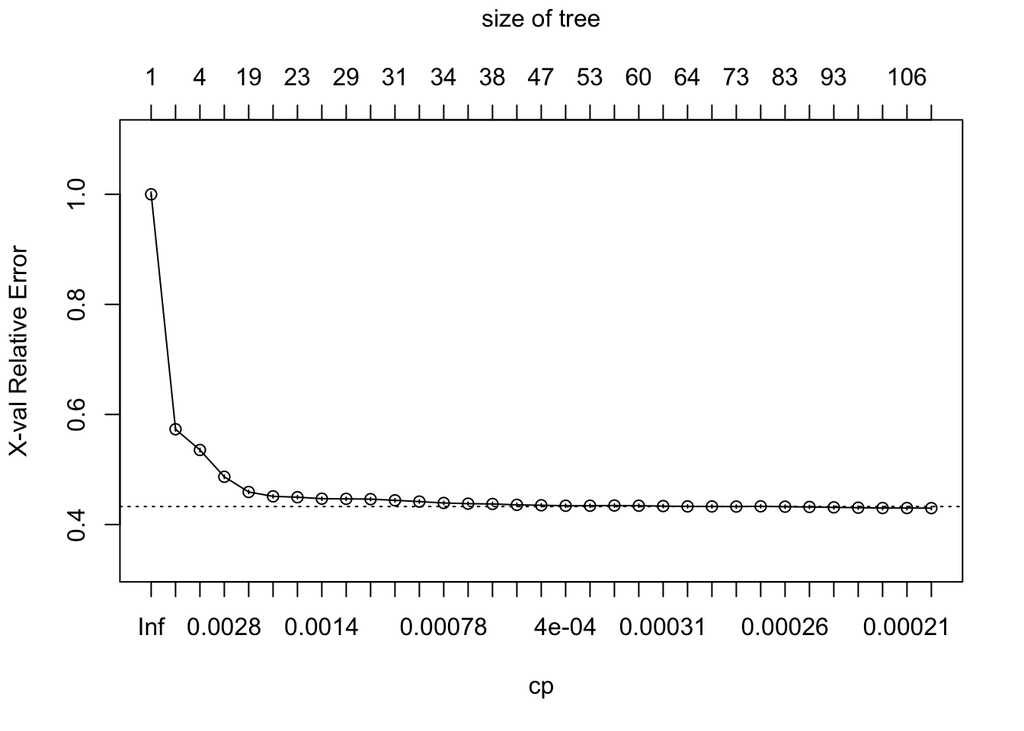

```r
plotcp(cv_gini_ct)
```

### 7.1.4 Extract Best `cp`

```r
best_cp_gini=cv_gini_ct$cptable[which.min(cv_gini_ct$cptable[,"xerror"]), "CP"]
```

### 7.1.5 Print Best `cp`

```r
print(best_cp_gini)
```

```
## [1] 0.0001977532
```

### 7.1.6 Select Best Prune Tree

```r
pruned_cv_gini_tree=prune(cv_gini_ct, cp=best_cp_gini)
```

### 7.1.7 Print Best Prune Tree

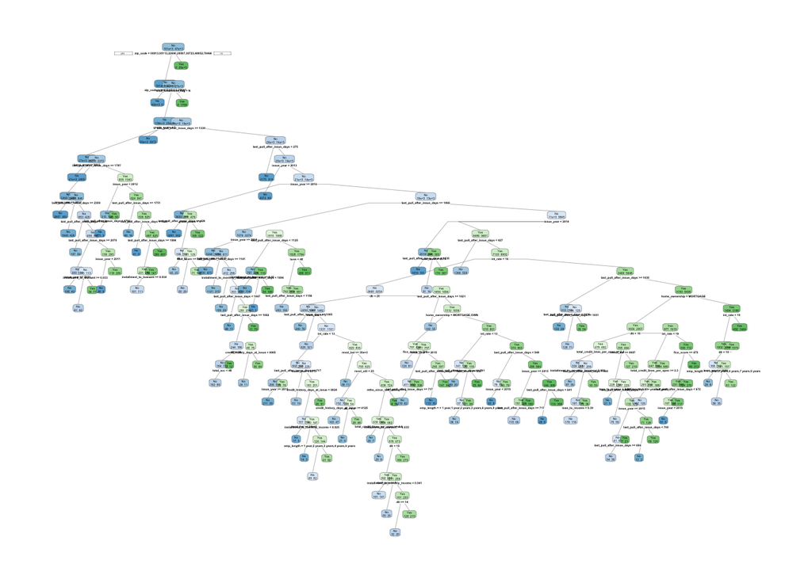

```r
rpart.plot(pruned_cv_gini_tree, extra=1, fallen.leaves=FALSE)
```

### 7.1.8 Obtain Variable Importance

```r
 print(pruned_cv_gini_tree$variable.importance)
```

```
##                      zip_code    last_pull_after_issue_days
##                  3.203261e+04                  5.019806e+03
##                    issue_year          debt_settlement_flag
##                  3.207897e+03                  2.299831e+03
##                   grade_score                      int_rate
##                  2.111516e+03                  2.015950e+03
##        installment_to_loanamt                    fico_score
##                  1.210953e+03                  6.066204e+02
##                          term               sub_grade_score
##                  5.287267e+02                  3.632590e+02
##                           dti           initial_list_status
##                  1.289649e+02                  8.702607e+01
##                     loan_amnt                      mort_acc
##                  8.531616e+01                  8.527091e+01
##                 log_loan_amnt                loan_to_income
##                  6.964847e+01                  6.931849e+01
##                home_ownership installment_to_monthly_income
##                  6.036629e+01                  5.831167e+01
##                    emp_length                     revol_bal
##                  3.746322e+01                  3.596831e+01
##   total_credit_lines_per_open           revol_bal_to_income
##                  3.469933e+01                  2.931832e+01
##                     total_acc                 log_revol_bal
##                  2.822306e+01                  2.620500e+01
##                log_annual_inc  credit_history_days_at_issue
##                  2.347583e+01                  2.147670e+01
## credit_history_years_at_issue                    revol_util
##                  2.134121e+01                  1.898572e+01
##            emp_length_numeric                      open_acc
##                  1.856196e+01                  1.637565e+01
##        mths_since_last_delinq              application_type
##                  1.166461e+01                  1.156932e+01
##                       purpose           verification_status
##                  8.564423e+00                  3.245285e+00
##        loan_amnt_outlier_flag                   delinq_2yrs
##                  3.155269e+00                  2.368508e+00
##        no_delinq_history_flag            any_current_delinq
##                  1.933019e+00                  1.874301e+00
##          pub_rec_outlier_flag       annual_inc_outlier_flag
##                  1.755423e+00                  1.214829e+00
##         mort_acc_outlier_flag              dti_outlier_flag
##                  7.938234e-01                  6.977371e-01
##                any_pub_record                       pub_rec
##                  5.793609e-01                  5.793609e-01
##                 pub_rec_group                any_bankruptcy
##                  5.793609e-01                  5.021128e-01
##        revol_bal_outlier_flag
##                  4.922725e-01
```

### 7.1.9 Predict on Holdout Dataset

#### 7.1.9.1 Predict Probabilities

```r
pruned_cv_gini_tree_prob <- predict(
  object = pruned_cv_gini_tree,
  newdata = hold,
  type = "prob"
)
```

#### 7.1.9.2 Predict Class

```r
pruned_cv_gini_tree_class <- predict(
  object = pruned_cv_gini_tree,
  newdata = hold,
  type = "class"
)
```

#### 7.1.9.3 Tabulate Predictions

```r
pruned_cv_gini_tree_predictions <- tibble::tibble(
  actual = factor(hold$loan_default, levels = c("No", "Yes")),
  predicted = factor(pruned_cv_gini_tree_class, levels = c("No", "Yes")),
  probability_yes = as.numeric(pruned_cv_gini_tree_prob[, "Yes"])
)
```

#### 7.1.9.4 Preview Table

```r
head(pruned_cv_gini_tree_predictions)
```

| actual | predicted | probability_yes |
| --- | --- | --- |
| Yes | Yes | 1.00000000 |
| No | No | 0.00000000 |
| No | Yes | 0.67500000 |
| No | No | 0.00000000 |
| No | No | 0.09439691 |
| No | No | 0.09563278 |

### 7.1.10 Evaluate

```r
pruned_cv_gini_tree_metrics <- evaluate_classifier(
  actual = pruned_cv_gini_tree_predictions$actual,
  predicted = pruned_cv_gini_tree_predictions$predicted,
  probability_yes = pruned_cv_gini_tree_predictions$probability_yes
)
```

### 7.1.11 Store & Export

#### 7.1.11.1 Save Model

```r
saveRDS(pruned_cv_gini_tree, file.path(project_dir, "pruned_cv_gini_tree_model.rds"))
```

#### 7.1.11.2 Save Results

```r
pruned_cv_gini_tree_results <- pruned_cv_gini_tree_metrics %>%
  mutate(
    model_type = "Cross-Validated Pruned Decision Tree",
    impurity = "Gini Index",
    sample = "Full"
  )

saveRDS(pruned_cv_gini_tree_results, file.path(project_dir, "pruned_cv_gini_tree_results.rds"))
```

## 7.2 *Undersampled Training Dataset*

### 7.2.1 Build Tree

```r
set.seed(123)
cv_gini_ct_us=rpart(loan_default ~ .,
                 data=train_under,
                 method="class",
                 parms=list(split="gini"),
                 control=rpart.control(
                   maxdepth=30,
                   cp=0.0001977532,
                   xval=15))
```

### 7.2.2 Print `cp`

```r
printcp(cv_gini_ct_us)
```

```
##
## Classification tree:
## rpart(formula = loan_default ~ ., data = train_under, method = "class",
##     parms = list(split = "gini"), control = rpart.control(maxdepth = 30,
##         cp = 0.0001977532, xval = 15))
##
## Variables actually used in tree construction:
##  [1] credit_history_days_at_issue  debt_settlement_flag
##  [3] dti                           emp_length
##  [5] fico_score                    grade_score
##  [7] home_ownership                installment_to_loanamt
##  [9] installment_to_monthly_income int_rate
## [11] issue_year                    last_pull_after_issue_days
## [13] loan_amnt                     loan_to_income
## [15] log_annual_inc                open_acc
```

[output cut: 53 more lines]

### 7.2.3 Plot `cp` Values

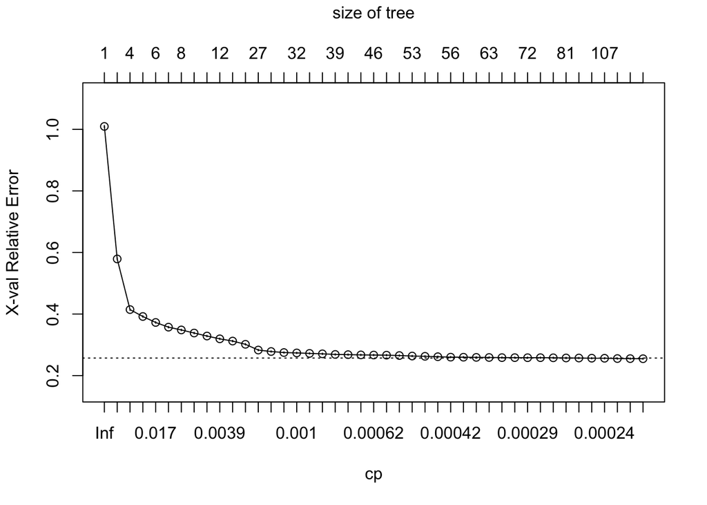

```r
plotcp(cv_gini_ct_us)
```

### 7.2.4 Extract Best `cp`

```r
best_cp_gini_us=cv_gini_ct_us$cptable[which.min(cv_gini_ct_us$cptable[,"xerror"]), "CP"]
```

### 7.2.5 Print Best `cp`

```r
print(best_cp_gini_us)
```

```
## [1] 0.0001977532
```

### 7.2.6 Select Best Prune Tree

```r
pruned_cv_gini_tree_us=prune(cv_gini_ct_us, cp=best_cp_gini_us)
```

### 7.2.7 Print Best Prune Tree

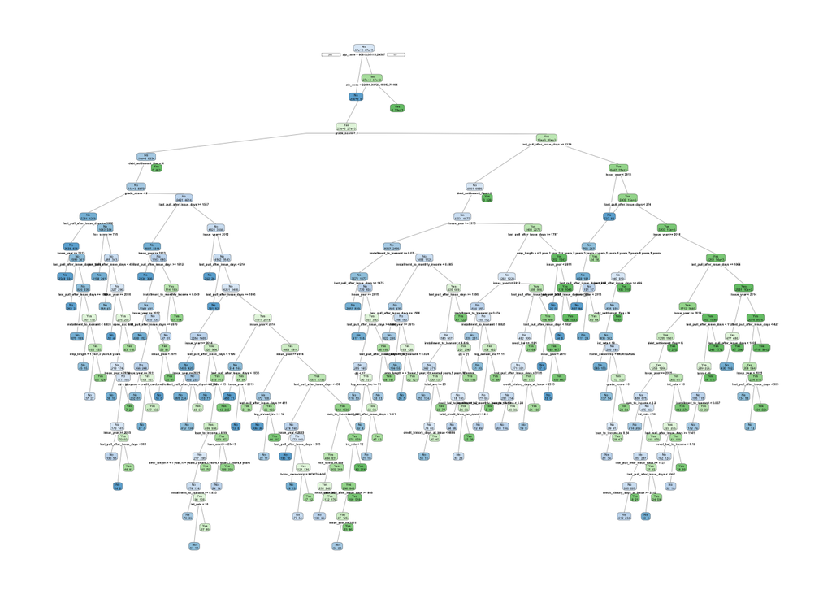

```r
rpart.plot(pruned_cv_gini_tree_us, extra=1, fallen.leaves=FALSE)
```

### 7.2.8 Obtain Variable Importance

```r
 print(pruned_cv_gini_tree_us$variable.importance)
```

```
##                      zip_code    last_pull_after_issue_days
##                  1.992301e+04                  3.763591e+03
##                    issue_year                   grade_score
##                  2.862519e+03                  2.517889e+03
##                      int_rate          debt_settlement_flag
##                  2.499867e+03                  1.181576e+03
##        installment_to_loanamt                    fico_score
##                  1.045885e+03                  6.508925e+02
##               sub_grade_score                          term
##                  4.120792e+02                  1.752403e+02
##                    revol_util                loan_to_income
##                  1.643461e+02                  1.505033e+02
## installment_to_monthly_income                     loan_amnt
##                  1.410215e+02                  1.214289e+02
##                 log_loan_amnt           initial_list_status
##                  1.195360e+02                  1.107918e+02
##           revol_bal_to_income                    emp_length
##                  9.168048e+01                  8.728590e+01
##           verification_status                      mort_acc
##                  7.742902e+01                  6.681591e+01
##                log_annual_inc                       purpose
##                  6.163544e+01                  5.640194e+01
##                           dti  credit_history_days_at_issue
##                  3.400744e+01                  3.045581e+01
##                     revol_bal credit_history_years_at_issue
##                  2.902533e+01                  2.855900e+01
##                 log_revol_bal                      open_acc
##                  2.713035e+01                  2.531161e+01
##        mths_since_last_delinq                home_ownership
##                  2.307455e+01                  2.257960e+01
##                     total_acc        no_delinq_history_flag
##                  2.099503e+01                  1.682330e+01
##   total_credit_lines_per_open              application_type
##                  1.129777e+01                  8.964274e+00
##                   delinq_2yrs                       pub_rec
##                  7.568392e+00                  6.428110e+00
##            emp_length_numeric       annual_inc_outlier_flag
##                  6.294314e+00                  2.371062e+00
##        loan_amnt_outlier_flag                 pub_rec_group
##                  2.271855e+00                  9.128086e-01
##            any_current_delinq          pub_rec_outlier_flag
##                  8.110401e-01                  7.103964e-01
##         mort_acc_outlier_flag          recent_inquiry_group
##                  4.959555e-01                  4.837498e-01
```

### 7.2.9 Predict on Holdout Dataset

#### 7.2.9.1 Predict Probabilities

```r
pruned_cv_gini_tree_us_prob <- predict(
  object = pruned_cv_gini_tree_us,
  newdata = hold,
  type = "prob"
)
```

#### 7.2.9.2 Predict Class

```r
pruned_cv_gini_tree_us_class <- predict(
  object = pruned_cv_gini_tree_us,
  newdata = hold,
  type = "class"
)
```

#### 7.2.9.3 Tabulate Predictions

```r
pruned_cv_gini_tree_predictions_us <- tibble::tibble(
  actual = factor(hold$loan_default, levels = c("No", "Yes")),
  predicted = factor(pruned_cv_gini_tree_us_class, levels = c("No", "Yes")),
  probability_yes = as.numeric(pruned_cv_gini_tree_us_prob[, "Yes"])
)
```

#### 7.2.9.4 Preview Table

```r
head(pruned_cv_gini_tree_predictions_us)
```

| actual | predicted | probability_yes |
| --- | --- | --- |
| Yes | Yes | 1.0000000 |
| No | No | 0.0000000 |
| No | Yes | 0.8400447 |
| No | No | 0.0000000 |
| No | Yes | 0.6266667 |
| No | No | 0.1992925 |

### 7.2.10 Evaluate

```r
pruned_cv_gini_tree_metrics_us <- evaluate_classifier(
  actual = pruned_cv_gini_tree_predictions_us$actual,
  predicted = pruned_cv_gini_tree_predictions_us$predicted,
  probability_yes = pruned_cv_gini_tree_predictions_us$probability_yes
)
```

### 7.2.11 Store & Export

#### 7.2.11.1 Save Model

```r
saveRDS(pruned_cv_gini_tree_us, file.path(project_dir, "pruned_cv_gini_tree_us_model.rds"))
```

#### 7.2.11.2 Save Results

```r
pruned_cv_gini_tree_results_us <- pruned_cv_gini_tree_metrics_us %>%
  mutate(
    model_type = "Cross-Validated Pruned Decision Tree",
    impurity = "Gini Index",
    sample = "Undersampled"
  )

saveRDS(pruned_cv_gini_tree_results_us, file.path(project_dir, "pruned_cv_gini_tree_us_results.rds"))
```

# 8 **Prune Tree With Cross Validation - Entropy Index Impurity Measure**

## 8.1 *Training Dataset*

### 8.1.1 Build Tree

```r
set.seed(123)
cv_entropy_ct=rpart(loan_default ~ .,
                 data=train,
                 method="class",
                 parms=list(split="information"),
                 control=rpart.control(cp=0.0002358743, xval=15)
                )
```

### 8.1.2 Print `cp`

```r
printcp(cv_entropy_ct)
```

```
##
## Classification tree:
## rpart(formula = loan_default ~ ., data = train, method = "class",
##     parms = list(split = "information"), control = rpart.control(cp = 0.0002358743,
##         xval = 15))
##
## Variables actually used in tree construction:
##  [1] debt_settlement_flag        dti
##  [3] emp_length                  fico_score
##  [5] grade_score                 home_ownership
##  [7] installment_to_loanamt      int_rate
##  [9] issue_year                  last_pull_after_issue_days
## [11] loan_to_income              mort_acc
## [13] revol_bal                   revol_util
## [15] sub_grade_score             term
```

[output cut: 36 more lines]

### 8.1.3 Plot `cp` Values

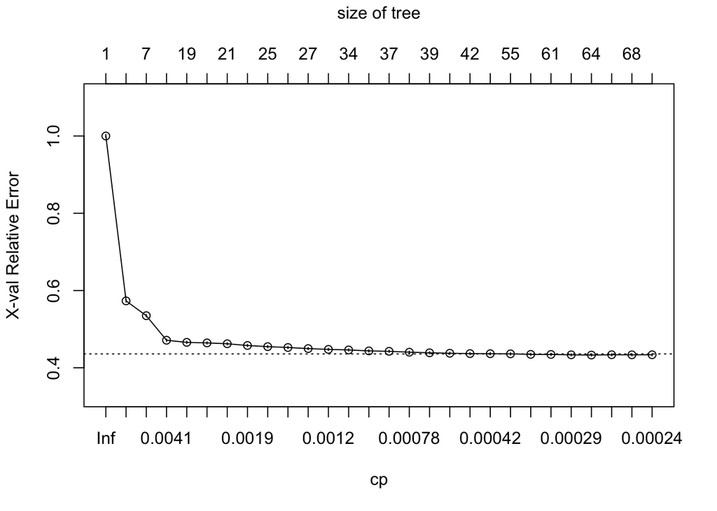

```r
plotcp(cv_entropy_ct) # plot the cp results against model size
```

### 8.1.4 Extract Best `cp`

```r
best_cp_entropy=cv_entropy_ct$cptable[which.min(cv_entropy_ct$cptable[,"xerror"]), "CP"] #pick the tree with the lowest cross validated error
```

### 8.1.5 Print Best `cp`

```r
print(best_cp_entropy)
```

```
## [1] 0.000268039
```

### 8.1.6 Select Best Prune Tree

```r
pruned_cv_entropy_tree=prune(cv_entropy_ct, cp=best_cp_entropy)
```

### 8.1.7 Print Best Prune Tree

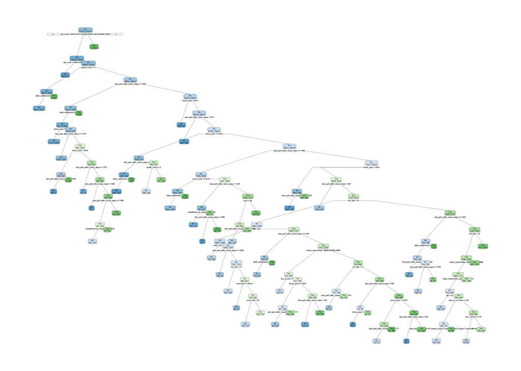

```r
rpart.plot(pruned_cv_entropy_tree, extra=1, fallen.leaves=FALSE)
```

### 8.1.8 Obtain Variable Importance

```r
print(pruned_cv_entropy_tree$variable.importance)
```

```
##                      zip_code    last_pull_after_issue_days
##                  5.031684e+04                  5.673901e+03
##                   grade_score                    issue_year
##                  3.619637e+03                  3.576763e+03
##                      int_rate          debt_settlement_flag
##                  3.249211e+03                  3.247218e+03
##        installment_to_loanamt                    fico_score
##                  1.801845e+03                  1.046198e+03
##                          term               sub_grade_score
##                  7.842407e+02                  6.043593e+02
##           initial_list_status                           dti
##                  1.121374e+02                  7.131671e+01
##                      mort_acc                     loan_amnt
##                  4.555862e+01                  4.536568e+01
##                home_ownership                loan_to_income
##                  4.376631e+01                  3.733429e+01
##                 log_loan_amnt                     revol_bal
##                  3.269623e+01                  2.183022e+01
##   total_credit_lines_per_open           revol_bal_to_income
##                  2.078120e+01                  2.071732e+01
## installment_to_monthly_income                    revol_util
##                  2.011735e+01                  1.918144e+01
##                 log_revol_bal                    emp_length
##                  1.737595e+01                  1.619262e+01
##                      open_acc                log_annual_inc
##                  1.502875e+01                  1.413394e+01
##                     total_acc              application_type
##                  1.316953e+01                  1.249525e+01
##  credit_history_days_at_issue credit_history_years_at_issue
##                  6.521298e+00                  6.521298e+00
##                       purpose            emp_length_numeric
##                  4.718997e+00                  3.706699e+00
##        loan_amnt_outlier_flag          pub_rec_outlier_flag
##                  3.259631e+00                  2.317509e+00
##        mths_since_last_delinq        revol_bal_outlier_flag
##                  1.808758e+00                  1.724090e+00
##            any_current_delinq         mort_acc_outlier_flag
##                  1.345370e+00                  8.000504e-01
##                   delinq_2yrs           verification_status
##                  5.783193e-01                  3.361420e-01
```

### 8.1.9 Predict on Holdout Dataset

#### 8.1.9.1 Predict Probabilities

```r
pruned_cv_entropy_tree_prob <- predict(
  object = pruned_cv_entropy_tree,
  newdata = hold,
  type = "prob"
)
```

#### 8.1.9.2 Predict Class

```r
pruned_cv_entropy_tree_class <- predict(
  object = pruned_cv_entropy_tree,
  newdata = hold,
  type = "class"
)
```

#### 8.1.9.3 Tabulate Predictions

```r
pruned_cv_entropy_tree_predictions <- tibble::tibble(
  actual = factor(hold$loan_default, levels = c("No", "Yes")),
  predicted = factor(pruned_cv_entropy_tree_class, levels = c("No", "Yes")),
  probability_yes = as.numeric(pruned_cv_entropy_tree_prob[, "Yes"])
)
```

#### 8.1.9.4 Preview Table

```r
head(pruned_cv_entropy_tree_predictions)
```

| actual | predicted | probability_yes |
| --- | --- | --- |
| Yes | Yes | 1.00000000 |
| No | No | 0.00000000 |
| No | Yes | 0.67500000 |
| No | No | 0.00000000 |
| No | No | 0.09439691 |
| No | No | 0.09563278 |

### 8.1.10 Evaluate

```r
pruned_cv_entropy_tree_metrics <- evaluate_classifier(
  actual = pruned_cv_entropy_tree_predictions$actual,
  predicted = pruned_cv_entropy_tree_predictions$predicted,
  probability_yes = pruned_cv_entropy_tree_predictions$probability_yes
)
```

### 8.1.11 Store & Export

#### 8.1.11.1 Save Model

```r
saveRDS(pruned_cv_entropy_tree, file.path(project_dir, "pruned_cv_entropy_tree_model.rds"))
```

#### 8.1.11.2 Save Results

```r
pruned_cv_entropy_tree_results <- pruned_cv_entropy_tree_metrics %>%
  mutate(
    model_type = "Cross-Validated Pruned Decision Tree",
    impurity = "Entropy Index",
    sample = "Full"
  )

saveRDS(pruned_cv_entropy_tree_results, file.path(project_dir, "pruned_cv_entropy_tree_results.rds"))
```

## 8.2 *Undersampled Training Dataset*

### 8.2.1 Build Tree

```r
set.seed(123)
cv_entropy_ct_us=rpart(loan_default ~ .,
                 data=train_under,
                 method="class",
                 parms=list(split="information"),
                 control=rpart.control(cp=0.0002358743, xval=15)
                )
```

### 8.2.2 Print `cp`

```r
printcp(cv_entropy_ct_us)
```

```
##
## Classification tree:
## rpart(formula = loan_default ~ ., data = train_under, method = "class",
##     parms = list(split = "information"), control = rpart.control(cp = 0.0002358743,
##         xval = 15))
##
## Variables actually used in tree construction:
##  [1] credit_history_days_at_issue  debt_settlement_flag
##  [3] dti                           emp_length
##  [5] fico_score                    grade_score
##  [7] home_ownership                installment_to_loanamt
##  [9] installment_to_monthly_income int_rate
## [11] issue_year                    last_pull_after_issue_days
## [13] loan_to_income                log_annual_inc
## [15] mths_since_last_delinq        open_acc
```

[output cut: 47 more lines]

### 8.2.3 Plot `cp` Values

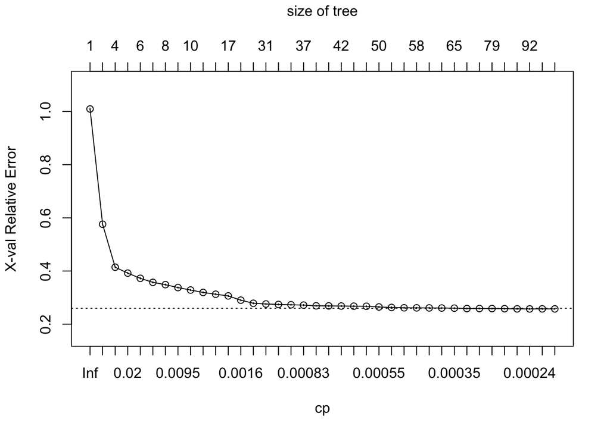

```r
plotcp(cv_entropy_ct_us) # plot the cp results against model size
```

### 8.2.4 Extract Best `cp`

```r
best_cp_entropy_us=cv_entropy_ct_us$cptable[which.min(cv_entropy_ct_us$cptable[,"xerror"]), "CP"] #pick the tree with the lowest cross validated error
```

### 8.2.5 Print Best `cp`

```r
print(best_cp_entropy_us)
```

```
## [1] 0.000240163
```

### 8.2.6 Select Best Prune Tree

```r
pruned_cv_entropy_tree_us=prune(cv_entropy_ct_us, cp=best_cp_entropy_us)
```

### 8.2.7 Print Best Prune Tree

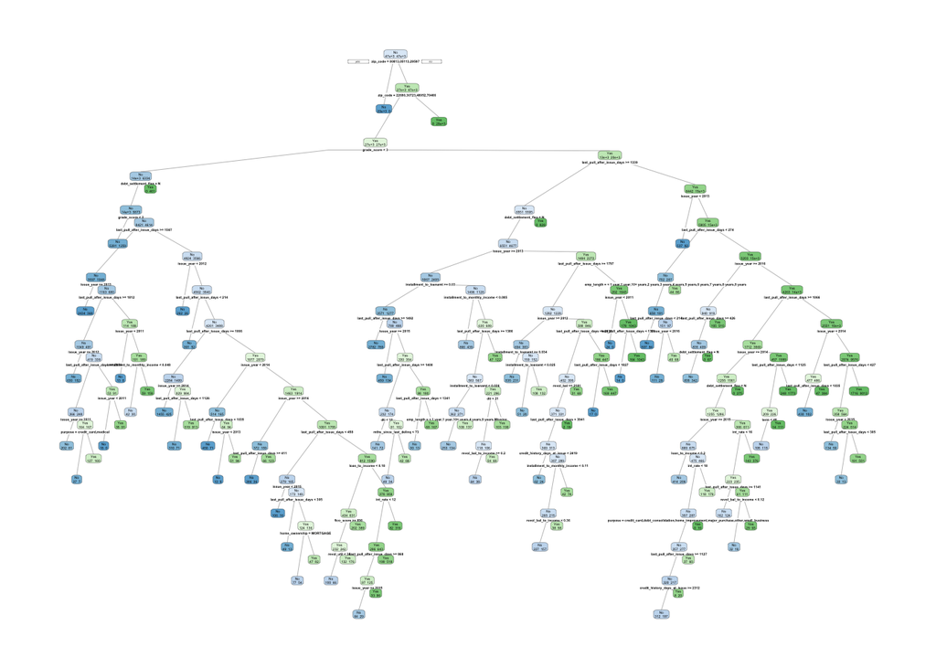

```r
rpart.plot(pruned_cv_entropy_tree_us, extra=1, fallen.leaves=FALSE)
```

### 8.2.8 Obtain Variable Importance

```r
print(pruned_cv_entropy_tree_us$variable.importance)
```

```
##                      zip_code    last_pull_after_issue_days
##                  2.761915e+04                  3.949696e+03
##                    issue_year                   grade_score
##                  3.092248e+03                  2.592037e+03
##                      int_rate          debt_settlement_flag
##                  2.523868e+03                  1.513732e+03
##        installment_to_loanamt                    fico_score
##                  1.058722e+03                  6.116140e+02
##               sub_grade_score                          term
##                  3.898459e+02                  1.871762e+02
##                    revol_util                loan_to_income
##                  1.519846e+02                  1.278561e+02
## installment_to_monthly_income           initial_list_status
##                  1.208471e+02                  1.198731e+02
##                     loan_amnt                 log_loan_amnt
##                  1.090508e+02                  1.081132e+02
##           revol_bal_to_income           verification_status
##                  9.427026e+01                  8.612023e+01
##                    emp_length                       purpose
##                  7.874058e+01                  6.742877e+01
##                      mort_acc                log_annual_inc
##                  6.121002e+01                  3.861059e+01
##                           dti                     revol_bal
##                  2.583404e+01                  2.546621e+01
##                 log_revol_bal  credit_history_days_at_issue
##                  2.508854e+01                  2.399030e+01
## credit_history_years_at_issue        mths_since_last_delinq
##                  2.282531e+01                  1.257949e+01
##                      open_acc              application_type
##                  1.193556e+01                  1.015809e+01
##                home_ownership                     total_acc
##                  9.012235e+00                  6.720949e+00
##            emp_length_numeric        no_delinq_history_flag
##                  6.426606e+00                  5.880815e+00
##   total_credit_lines_per_open        loan_amnt_outlier_flag
##                  4.613517e+00                  2.499091e+00
##                   delinq_2yrs       annual_inc_outlier_flag
##                  1.450438e+00                  1.377119e+00
##                 pub_rec_group        revol_bal_outlier_flag
##                  1.127406e+00                  4.921498e-01
##          recent_inquiry_group            any_current_delinq
##                  4.886528e-01                  3.002050e-01
```

### 8.2.9 Predict on Holdout Dataset

#### 8.2.9.1 Predict Probabilities

```r
pruned_cv_entropy_tree_us_prob <- predict(
  object = pruned_cv_entropy_tree_us,
  newdata = hold,
  type = "prob"
)
```

#### 8.2.9.2 Predict Class

```r
pruned_cv_entropy_tree_us_class <- predict(
  object =pruned_cv_entropy_tree_us,
  newdata = hold,
  type = "class"
)
```

#### 8.2.9.3 Tabulate Predictions

```r
pruned_cv_entropy_tree_predictions_us <- tibble::tibble(
  actual = factor(hold$loan_default, levels = c("No", "Yes")),
  predicted = factor(pruned_cv_entropy_tree_us_class, levels = c("No", "Yes")),
  probability_yes = as.numeric(pruned_cv_entropy_tree_us_prob[, "Yes"])
)
```

#### 8.2.9.4 Preview Table

```r
head(pruned_cv_entropy_tree_predictions_us)
```

| actual | predicted | probability_yes |
| --- | --- | --- |
| Yes | Yes | 1.0000000 |
| No | No | 0.0000000 |
| No | Yes | 0.8400447 |
| No | No | 0.0000000 |
| No | No | 0.2905692 |
| No | No | 0.1925076 |

### 8.2.10 Evaluate

```r
pruned_cv_entropy_tree_metrics_us <- evaluate_classifier(
  actual = pruned_cv_entropy_tree_predictions_us$actual,
  predicted = pruned_cv_entropy_tree_predictions_us$predicted,
  probability_yes = pruned_cv_entropy_tree_predictions_us$probability_yes
)
```

### 8.2.11 Store & Export

#### 8.2.11.1 Save Model

```r
saveRDS(pruned_cv_entropy_tree_us, file.path(project_dir, "pruned_cv_entropy_tree_us_model.rds"))
```

#### 8.2.11.2 Save Results

```r
pruned_cv_entropy_tree_results_us <- pruned_cv_entropy_tree_metrics_us %>%
  mutate(
    model_type = "Cross-Validated Pruned Decision Tree",
    impurity = "Entropy Index",
    sample = "Undersampled"
  )

saveRDS(pruned_cv_entropy_tree_results_us, file.path(project_dir, "pruned_cv_entropy_tree_us_results.rds"))
```